# project 1

```python
import numpy as np
import pandas as pd
import matplotlib.pyplot as plt
import seaborn as sns
import matplotlib.image as mpimg
from sklearn.model_selection import train_test_split
from sklearn.linear_model import LinearRegression
from sklearn.metrics import mean_squared_error
```

Features description

date : the date of the game

time : the time of the game

comp : the competition of the game

round : the round of the game

day : the day of the week of the game

venue : the venue of the game

result : the result of the game

gf : the goals for the home team

ga : the goals for the away team

opponent: the opponent of the home team

xg : the expected goals for the home team

xga : the expected goals for the away team

poss : the possession of the home team

captain : the captain of the home team

formation : the formation of the home team

referee : the referee of the game

sh : the shots of the home team

sot : the shots on target of the home team

dist : the average distance of the shots of the home team

fk : the free kicks of the home team

pk : the penalty kicks of the home team

pka : the penalty kicks attempted of the home team

season : the season year of the match

team: the home team

# Preprocessing and Data Cleaning

```python
df = pd.read_csv('D:\\projects\\datasets\\matches.csv',encoding='utf-8')
pd.set_option('display.max_columns',len(df.columns))
df_c = df.copy()
df_c
```

|  | Unnamed: 0 | date | time | comp | round | day | venue | result | gf | ga | opponent | xg | xga | poss | attendance | captain | formation | referee | match report | notes | sh | sot | dist | fk | pk | pkatt | season | team |
| --- | --- | --- | --- | --- | --- | --- | --- | --- | --- | --- | --- | --- | --- | --- | --- | --- | --- | --- | --- | --- | --- | --- | --- | --- | --- | --- | --- | --- |
| 0 | 0 | 2020-09-21 | 20:15 (21:15) | Premier League | Matchweek 2 | Mon | Away | W | 3 | 1 | Wolves | 1.9 | 0.6 | 65 | NaN | Fernandinho | 4-2-3-1 | Andre Marriner | Match Report | NaN | 13 | 8 | 21.1 | 2 | 1 | 1 | 2024 | Manchester City |
| 1 | 2 | 2020-09-27 | 16:30 (17:30) | Premier League | Matchweek 3 | Sun | Home | L | 2 | 5 | Leicester City | 0.9 | 2.9 | 72 | NaN | Fernandinho | 4-2-3-1 | Michael Oliver | Match Report | NaN | 16 | 5 | 19.8 | 1 | 0 | 0 | 2024 | Manchester City |
| 2 | 4 | 2020-10-03 | 17:30 (18:30) | Premier League | Matchweek 4 | Sat | Away | D | 1 | 1 | Leeds United | 1.2 | 2.4 | 49 | NaN | Kevin De Bruyne | 4-3-3 | Mike Dean | Match Report | NaN | 23 | 1 | 18.2 | 1 | 0 | 0 | 2024 | Manchester City |
| 3 | 5 | 2020-10-17 | 17:30 (18:30) | Premier League | Matchweek 5 | Sat | Home | W | 1 | 0 | Arsenal | 1.3 | 0.9 | 58 | NaN | Raheem Sterling | 3-1-4-2 | Chris Kavanagh | Match Report | NaN | 13 | 5 | 17.7 | 0 | 0 | 0 | 2024 | Manchester City |
| 4 | 7 | 2020-10-24 | 12:30 (13:30) | Premier League | Matchweek 6 | Sat | Away | D | 1 | 1 | West Ham | 1.0 | 0.3 | 69 | NaN | Raheem Sterling | 4-3-3 | Anthony Taylor | Match Report | NaN | 14 | 7 | 20.9 | 1 | 0 | 0 | 2024 | Manchester City |
| ... | ... | ... | ... | ... | ... | ... | ... | ... | ... | ... | ... | ... | ... | ... | ... | ... | ... | ... | ... | ... | ... | ... | ... | ... | ... | ... | ... | ... |
| 4783 | 87 | 2020-07-07 | 18:00 (19:00) | Premier League | Matchweek 34 | Tue | Away | L | 1 | 2 | Watford | 1.2 | 1.2 | 56 | NaN | Alexander Tettey | 4-2-3-1 | Anthony Taylor | Match Report | NaN | 12 | 3 | 16.9 | 1 | 0 | 0 | 2020 | Norwich City |
| 4784 | 88 | 2020-07-11 | 12:30 (13:30) | Premier League | Matchweek 35 | Sat | Home | L | 0 | 4 | West Ham | 0.6 | 3.5 | 53 | NaN | Alexander Tettey | 4-2-3-1 | Kevin Friend | Match Report | NaN | 11 | 2 | 19.8 | 1 | 0 | 0 | 2020 | Norwich City |
| 4785 | 89 | 2020-07-14 | 20:15 (21:15) | Premier League | Matchweek 36 | Tue | Away | L | 0 | 1 | Chelsea | 0.1 | 2.5 | 33 | NaN | Alexander Tettey | 4-1-4-1 | Jonathan Moss | Match Report | NaN | 2 | 0 | 20.6 | 0 | 0 | 0 | 2020 | Norwich City |
| 4786 | 90 | 2020-07-18 | 17:30 (18:30) | Premier League | Matchweek 37 | Sat | Home | L | 0 | 2 | Burnley | 0.3 | 1.8 | 42 | NaN | Alexander Tettey | 4-2-3-1 | Kevin Friend | Match Report | NaN | 6 | 2 | 13.4 | 0 | 0 | 0 | 2020 | Norwich City |
| 4787 | 91 | 2020-07-26 | 16:00 (17:00) | Premier League | Matchweek 38 | Sun | Away | L | 0 | 5 | Manchester City | 1.0 | 3.2 | 27 | NaN | Christoph Zimmermann | 4-2-3-1 | Craig Pawson | Match Report | NaN | 5 | 4 | 19.8 | 0 | 0 | 0 | 2020 | Norwich City |

4788 rows × 28 columns

```python
df_c.rename(columns=lambda x: x.strip().lower().replace(' ', '_'), inplace=True)
```

```python
df_c.shape
```

```
(4788, 28)
```

```python
df_c.describe()
```

|  | unnamed:_0 | gf | ga | xg | xga | poss | attendance | notes | sh | sot | dist | fk | pk | pkatt | season |
| --- | --- | --- | --- | --- | --- | --- | --- | --- | --- | --- | --- | --- | --- | --- | --- |
| count | 4788.000000 | 4788.000000 | 4788.000000 | 4788.000000 | 4788.000000 | 4788.000000 | 3155.000000 | 0.0 | 4788.000000 | 4788.000000 | 4786.000000 | 4788.000000 | 4788.000000 | 4788.00000 | 4788.000000 |
| mean | 63.044069 | 1.447995 | 1.405388 | 1.396512 | 1.364745 | 50.432957 | 38397.586688 | NaN | 12.619256 | 4.261278 | 17.356247 | 0.453216 | 0.118212 | 0.14599 | 2022.365079 |
| std | 42.865191 | 1.312635 | 1.286927 | 0.828847 | 0.814947 | 12.810958 | 17595.849137 | NaN | 5.548444 | 2.459963 | 3.049341 | 0.665250 | 0.342362 | 0.37937 | 1.461850 |
| min | 0.000000 | 0.000000 | 0.000000 | 0.000000 | 0.000000 | 18.000000 | 2000.000000 | NaN | 0.000000 | 0.000000 | 5.300000 | 0.000000 | 0.000000 | 0.00000 | 2020.000000 |
| 25% | 28.000000 | 0.000000 | 0.000000 | 0.800000 | 0.700000 | 41.000000 | 25513.500000 | NaN | 9.000000 | 2.000000 | 15.400000 | 0.000000 | 0.000000 | 0.00000 | 2021.000000 |
| 50% | 62.000000 | 1.000000 | 1.000000 | 1.300000 | 1.200000 | 51.000000 | 36347.000000 | NaN | 12.000000 | 4.000000 | 17.200000 | 0.000000 | 0.000000 | 0.00000 | 2023.000000 |
| 75% | 87.000000 | 2.000000 | 2.000000 | 1.900000 | 1.800000 | 60.000000 | 53235.500000 | NaN | 16.000000 | 6.000000 | 19.100000 | 1.000000 | 0.000000 | 0.00000 | 2024.000000 |
| max | 182.000000 | 9.000000 | 9.000000 | 7.000000 | 7.000000 | 82.000000 | 75546.000000 | NaN | 36.000000 | 15.000000 | 39.900000 | 4.000000 | 3.000000 | 3.00000 | 2024.000000 |

```python
df_c.info()
```

```
<class 'pandas.core.frame.DataFrame'>
RangeIndex: 4788 entries, 0 to 4787
Data columns (total 28 columns):
 #   Column        Non-Null Count  Dtype
---  ------        --------------  -----
 0   unnamed:_0    4788 non-null   int64
 1   date          4788 non-null   object
 2   time          4788 non-null   object
 3   comp          4788 non-null   object
 4   round         4788 non-null   object
 5   day           4788 non-null   object
 6   venue         4788 non-null   object
 7   result        4788 non-null   object
 8   gf            4788 non-null   int64
 9   ga            4788 non-null   int64
```

[output cut: 20 more lines]

```python
df_c.isna().sum().to_frame()
```

|  | 0 |
| --- | --- |
| unnamed:_0 | 0 |
| date | 0 |
| time | 0 |
| comp | 0 |
| round | 0 |
| day | 0 |
| venue | 0 |
| result | 0 |
| gf | 0 |
| ga | 0 |
| opponent | 0 |
| xg | 0 |
| xga | 0 |
| poss | 0 |
| attendance | 1633 |
| captain | 0 |
| formation | 0 |
| referee | 0 |
| match_report | 0 |
| notes | 4788 |
| sh | 0 |
| sot | 0 |
| dist | 2 |
| fk | 0 |
| pk | 0 |
| pkatt | 0 |
| season | 0 |
| team | 0 |

```python
df_c = df_c.drop(['notes', 'comp', 'time','match_report',df_c.columns[0]], axis=1) ## df_c.drop(columns=['notes'],inplace=True)
df_c
```

|  | date | round | day | venue | result | gf | ga | opponent | xg | xga | poss | attendance | captain | formation | referee | sh | sot | dist | fk | pk | pkatt | season | team |
| --- | --- | --- | --- | --- | --- | --- | --- | --- | --- | --- | --- | --- | --- | --- | --- | --- | --- | --- | --- | --- | --- | --- | --- |
| 0 | 2020-09-21 | Matchweek 2 | Mon | Away | W | 3 | 1 | Wolves | 1.9 | 0.6 | 65 | NaN | Fernandinho | 4-2-3-1 | Andre Marriner | 13 | 8 | 21.1 | 2 | 1 | 1 | 2024 | Manchester City |
| 1 | 2020-09-27 | Matchweek 3 | Sun | Home | L | 2 | 5 | Leicester City | 0.9 | 2.9 | 72 | NaN | Fernandinho | 4-2-3-1 | Michael Oliver | 16 | 5 | 19.8 | 1 | 0 | 0 | 2024 | Manchester City |
| 2 | 2020-10-03 | Matchweek 4 | Sat | Away | D | 1 | 1 | Leeds United | 1.2 | 2.4 | 49 | NaN | Kevin De Bruyne | 4-3-3 | Mike Dean | 23 | 1 | 18.2 | 1 | 0 | 0 | 2024 | Manchester City |
| 3 | 2020-10-17 | Matchweek 5 | Sat | Home | W | 1 | 0 | Arsenal | 1.3 | 0.9 | 58 | NaN | Raheem Sterling | 3-1-4-2 | Chris Kavanagh | 13 | 5 | 17.7 | 0 | 0 | 0 | 2024 | Manchester City |
| 4 | 2020-10-24 | Matchweek 6 | Sat | Away | D | 1 | 1 | West Ham | 1.0 | 0.3 | 69 | NaN | Raheem Sterling | 4-3-3 | Anthony Taylor | 14 | 7 | 20.9 | 1 | 0 | 0 | 2024 | Manchester City |
| ... | ... | ... | ... | ... | ... | ... | ... | ... | ... | ... | ... | ... | ... | ... | ... | ... | ... | ... | ... | ... | ... | ... | ... |
| 4783 | 2020-07-07 | Matchweek 34 | Tue | Away | L | 1 | 2 | Watford | 1.2 | 1.2 | 56 | NaN | Alexander Tettey | 4-2-3-1 | Anthony Taylor | 12 | 3 | 16.9 | 1 | 0 | 0 | 2020 | Norwich City |
| 4784 | 2020-07-11 | Matchweek 35 | Sat | Home | L | 0 | 4 | West Ham | 0.6 | 3.5 | 53 | NaN | Alexander Tettey | 4-2-3-1 | Kevin Friend | 11 | 2 | 19.8 | 1 | 0 | 0 | 2020 | Norwich City |
| 4785 | 2020-07-14 | Matchweek 36 | Tue | Away | L | 0 | 1 | Chelsea | 0.1 | 2.5 | 33 | NaN | Alexander Tettey | 4-1-4-1 | Jonathan Moss | 2 | 0 | 20.6 | 0 | 0 | 0 | 2020 | Norwich City |
| 4786 | 2020-07-18 | Matchweek 37 | Sat | Home | L | 0 | 2 | Burnley | 0.3 | 1.8 | 42 | NaN | Alexander Tettey | 4-2-3-1 | Kevin Friend | 6 | 2 | 13.4 | 0 | 0 | 0 | 2020 | Norwich City |
| 4787 | 2020-07-26 | Matchweek 38 | Sun | Away | L | 0 | 5 | Manchester City | 1.0 | 3.2 | 27 | NaN | Christoph Zimmermann | 4-2-3-1 | Craig Pawson | 5 | 4 | 19.8 | 0 | 0 | 0 | 2020 | Norwich City |

4788 rows × 23 columns

```python
df_c.isna().sum()
```

```
date             0
round            0
day              0
venue            0
result           0
gf               0
ga               0
opponent         0
xg               0
xga              0
poss             0
attendance    1633
captain          0
formation        0
referee          0
sh               0
sot              0
dist             2
fk               0
pk               0
pkatt            0
season           0
team             0
dtype: int64
```

```python
print(df_c.duplicated().sum(),"\n" )
print(df_c.nunique().to_frame())
```

```
0

               0
date         610
round         38
day            7
venue          2
result         3
gf            10
ga            10
opponent      26
xg            51
xga           51
poss          65
attendance  1344
captain      178
formation     22
referee       35
sh            35
sot           16
dist         193
fk             5
pk             4
pkatt          4
season         5
team          26
```

there are

26 teams

5 seasons

35 referee

38 rounds

```python
print(df_c['attendance'].mean())
print(df_c['attendance'].median())
print(df_c['attendance'].mode()[0])

df_c['attendance'].fillna(df_c['attendance'].mode()[0],inplace=True)
df_c.sample(5)
```

```
38397.58668779715
36347.0
2000.0
```

|  | date | round | day | venue | result | gf | ga | opponent | xg | xga | poss | attendance | captain | formation | referee | sh | sot | dist | fk | pk | pkatt | season | team |
| --- | --- | --- | --- | --- | --- | --- | --- | --- | --- | --- | --- | --- | --- | --- | --- | --- | --- | --- | --- | --- | --- | --- | --- |
| 2510 | 2021-08-28 | Matchweek 3 | Sat | Home | W | 5 | 0 | Arsenal | 4.4 | 0.2 | 80 | 52276.0 | İlkay Gündoğan | 4-3-3 | Martin Atkinson | 25 | 10 | 14.8 | 0 | 0 | 0 | 2022 | Manchester City |
| 839 | 2019-08-31 | Matchweek 4 | Sat | Away | D | 1 | 1 | Southampton | 1.5 | 0.9 | 59 | 30499.0 | Ashley Young | 4-2-3-1 | Mike Dean | 21 | 8 | 17.6 | 0 | 0 | 0 | 2023 | Manchester United |
| 2848 | 2022-05-15 | Matchweek 37 | Sun | Away | D | 1 | 1 | Leeds United | 2.2 | 1.6 | 50 | 36638.0 | Lewis Dunk | 3-4-3 | Mike Dean | 15 | 6 | 14.3 | 0 | 0 | 0 | 2022 | Brighton and Hove Albion |
| 4302 | 2019-10-21 | Matchweek 9 | Mon | Away | L | 0 | 1 | Sheffield Utd | 1.0 | 0.9 | 67 | 30775.0 | Granit Xhaka | 4-2-3-1 | Mike Dean | 9 | 3 | 18.8 | 1 | 0 | 0 | 2020 | Arsenal |
| 1279 | 2024-02-24 | Matchweek 26 | Sat | Home | L | 1 | 2 | Fulham | 1.7 | 1.2 | 57 | 73487.0 | Bruno Fernandes | 4-2-3-1 | Michael Oliver | 21 | 8 | 17.3 | 0 | 0 | 0 | 2024 | Manchester United |

```python
df_c.dropna(inplace=True)
df_c.isna().sum().sum()
```

```
0
```

```python
conditions = [
    df_c['venue'] == "Home" ,
    df_c['venue']== "Away"
]
values = [1,2]
df_c['venue'] = np.select(conditions,values,0)
df_c.sample(5)
```

|  | date | round | day | venue | result | gf | ga | opponent | xg | xga | poss | attendance | captain | formation | referee | sh | sot | dist | fk | pk | pkatt | season | team |
| --- | --- | --- | --- | --- | --- | --- | --- | --- | --- | --- | --- | --- | --- | --- | --- | --- | --- | --- | --- | --- | --- | --- | --- |
| 4427 | 2019-12-28 | Matchweek 20 | Sat | 1 | D | 1 | 1 | Crystal Palace | 1.4 | 0.3 | 59 | 31108.0 | Pierre Højbjerg | 4-4-2 | Andy Madley | 14 | 5 | 15.8 | 1 | 0 | 0 | 2020 | Southampton |
| 1266 | 2023-11-26 | Matchweek 13 | Sun | 2 | W | 3 | 0 | Everton | 2.2 | 2.4 | 49 | 39257.0 | Bruno Fernandes | 4-2-3-1 | John Brooks | 8 | 3 | 17.4 | 0 | 1 | 1 | 2024 | Manchester United |
| 2714 | 2021-12-27 | Matchweek 19 | Mon | 2 | D | 1 | 1 | Newcastle Utd | 1.6 | 1.3 | 68 | 52178.0 | Harry Maguire | 4-2-2-2 | Craig Pawson | 13 | 3 | 17.9 | 0 | 0 | 0 | 2022 | Manchester United |
| 317 | 2020-12-20 | Matchweek 14 | Sun | 2 | L | 2 | 6 | Manchester Utd | 1.8 | 3.6 | 59 | 2000.0 | Liam Cooper | 4-1-4-1 | Anthony Taylor | 17 | 4 | 13.9 | 0 | 0 | 0 | 2024 | Leeds United |
| 1469 | 2024-02-24 | Matchweek 26 | Sat | 2 | W | 2 | 1 | Manchester Utd | 1.2 | 1.7 | 43 | 73487.0 | Harrison Reed | 4-2-3-1 | Michael Oliver | 17 | 5 | 17.1 | 0 | 0 | 0 | 2024 | Fulham |

```python
# Define conditions for each possible result
conditions = [
    df_c['result'] == 'W',
    df_c['result'] == 'D',
    df_c['result'] == 'L'
]

# Define corresponding values for each condition
values = [1, 0, -1]

df_c['result'] = np.select(conditions, values,0)
df_c.sample(5)
```

|  | date | round | day | venue | result | gf | ga | opponent | xg | xga | poss | attendance | captain | formation | referee | sh | sot | dist | fk | pk | pkatt | season | team |
| --- | --- | --- | --- | --- | --- | --- | --- | --- | --- | --- | --- | --- | --- | --- | --- | --- | --- | --- | --- | --- | --- | --- | --- |
| 4787 | 2020-07-26 | Matchweek 38 | Sun | 2 | -1 | 0 | 5 | Manchester City | 1.0 | 3.2 | 27 | 2000.0 | Christoph Zimmermann | 4-2-3-1 | Craig Pawson | 5 | 4 | 19.8 | 0 | 0 | 0 | 2020 | Norwich City |
| 1532 | 2023-11-26 | Matchweek 13 | Sun | 1 | -1 | 0 | 3 | Manchester Utd | 2.4 | 2.2 | 51 | 39257.0 | James Tarkowski | 4-4-1-1 | John Brooks | 24 | 6 | 16.9 | 0 | 0 | 0 | 2024 | Everton |
| 1573 | 2023-12-09 | Matchweek 16 | Sat | 2 | -1 | 0 | 1 | Sheffield Utd | 0.6 | 0.8 | 59 | 28509.0 | Christian Nørgaard | 4-3-3 | Stuart Attwell | 10 | 4 | 16.7 | 0 | 0 | 0 | 2024 | Brentford |
| 2206 | 2022-08-20 | Matchweek 3 | Sat | 2 | -1 | 0 | 1 | Tottenham | 0.7 | 1.7 | 50 | 61298.0 | Rúben Neves | 3-5-2 | Simon Hooper | 20 | 3 | 21.9 | 1 | 0 | 0 | 2023 | Wolverhampton Wanderers |
| 1453 | 2023-10-29 | Matchweek 10 | Sun | 2 | 0 | 1 | 1 | Brighton | 0.7 | 1.4 | 29 | 31550.0 | Tim Ream | 4-2-3-1 | Michael Salisbury | 10 | 5 | 19.3 | 0 | 0 | 0 | 2024 | Fulham |

```python
df_c['day'] = df_c['day'].str.strip().str.lower()
df_c['day'].sample(5)
```

```
35      fri
2620    thu
4691    sat
1375    sun
335     mon
Name: day, dtype: object
```

```python
conditions = [
    df_c['day']=='sat' ,
    df_c['day']=='sun',
    df_c['day']=='mon',
    df_c['day']=='tue',
    df_c['day']=='wed',
    df_c['day']=='thu' ,
    df_c['day']=='fri'
]

values = [1,2,3,4,5,6,7]

df_c['day'] = np.select(conditions, values,0)
df_c.sample(5)
```

|  | date | round | day | venue | result | gf | ga | opponent | xg | xga | poss | attendance | captain | formation | referee | sh | sot | dist | fk | pk | pkatt | season | team |
| --- | --- | --- | --- | --- | --- | --- | --- | --- | --- | --- | --- | --- | --- | --- | --- | --- | --- | --- | --- | --- | --- | --- | --- |
| 1102 | 2023-08-12 | Matchweek 1 | 1 | 2 | -1 | 1 | 5 | Newcastle Utd | 1.8 | 3.3 | 48 | 52207.0 | John McGinn | 4-2-3-1 | Andy Madley | 16 | 6 | 14.5 | 1 | 0 | 0 | 2024 | Aston Villa |
| 2972 | 2021-10-24 | Matchweek 9 | 2 | 1 | -1 | 1 | 2 | Leicester City | 1.0 | 1.5 | 54 | 16814.0 | Pontus Jansson | 3-5-2 | Simon Hooper | 15 | 5 | 16.3 | 0 | 0 | 0 | 2022 | Brentford |
| 1897 | 2023-05-18 | Matchweek 25 | 6 | 1 | 1 | 4 | 1 | Brighton | 3.6 | 0.5 | 35 | 52122.0 | Kieran Trippier | 4-3-3 | Robert Jones | 22 | 8 | 13.3 | 1 | 0 | 0 | 2023 | Newcastle United |
| 4460 | 2019-12-04 | Matchweek 15 | 5 | 2 | -1 | 2 | 5 | Liverpool | 1.5 | 2.0 | 42 | 53094.0 | Gylfi Sigurðsson | 5-4-1 | Mike Dean | 12 | 4 | 15.5 | 1 | 0 | 0 | 2020 | Everton |
| 4372 | 2019-08-25 | Matchweek 3 | 2 | 2 | 0 | 1 | 1 | Wolves | 1.6 | 1.5 | 35 | 30522.0 | Ben Mee | 4-4-2 | Craig Pawson | 13 | 4 | 16.3 | 0 | 0 | 0 | 2020 | Burnley |

```python
x = df_c['result'].value_counts()
x
```

```
result
 1    1895
-1    1820
 0    1071
Name: count, dtype: int64
```

```python
df_c['date'] = pd.to_datetime(df_c['date'], format='%Y-%m-%d')
df_c['date'].sample(5)
```

```
2381   2023-03-05
4547   2020-02-08
4490   2019-09-29
4189   2019-10-25
2938   2021-11-27
Name: date, dtype: datetime64[ns]
```

```
29      Sergio Agüero
30        Fernandinho
31        Fernandinho
32     İlkay Gündoğan
33        Fernandinho
34    Raheem Sterling
35    Raheem Sterling
Name: captain, dtype: object
```

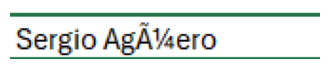

```python
print(df_c.loc[29:35,'captain'],"\n")  ## transform the latin words into eng

# Load the image
img = mpimg.imread('D:\\projects\\sergio.PNG')  # Use the correct path to your image

# Display the image
plt.figure(figsize=(4, 2))
plt.imshow(img)
plt.axis('off')  # Hide the axis
plt.show()
```

```python
df_c.loc[0:5,]
```

|  | date | round | day | venue | result | gf | ga | opponent | xg | xga | poss | attendance | captain | formation | referee | sh | sot | dist | fk | pk | pkatt | season | team |
| --- | --- | --- | --- | --- | --- | --- | --- | --- | --- | --- | --- | --- | --- | --- | --- | --- | --- | --- | --- | --- | --- | --- | --- |
| 0 | 2020-09-21 | Matchweek 2 | 3 | 2 | 1 | 3 | 1 | Wolves | 1.9 | 0.6 | 65 | 2000.0 | Fernandinho | 4-2-3-1 | Andre Marriner | 13 | 8 | 21.1 | 2 | 1 | 1 | 2024 | Manchester City |
| 1 | 2020-09-27 | Matchweek 3 | 2 | 1 | -1 | 2 | 5 | Leicester City | 0.9 | 2.9 | 72 | 2000.0 | Fernandinho | 4-2-3-1 | Michael Oliver | 16 | 5 | 19.8 | 1 | 0 | 0 | 2024 | Manchester City |
| 2 | 2020-10-03 | Matchweek 4 | 1 | 2 | 0 | 1 | 1 | Leeds United | 1.2 | 2.4 | 49 | 2000.0 | Kevin De Bruyne | 4-3-3 | Mike Dean | 23 | 1 | 18.2 | 1 | 0 | 0 | 2024 | Manchester City |
| 3 | 2020-10-17 | Matchweek 5 | 1 | 1 | 1 | 1 | 0 | Arsenal | 1.3 | 0.9 | 58 | 2000.0 | Raheem Sterling | 3-1-4-2 | Chris Kavanagh | 13 | 5 | 17.7 | 0 | 0 | 0 | 2024 | Manchester City |
| 4 | 2020-10-24 | Matchweek 6 | 1 | 2 | 0 | 1 | 1 | West Ham | 1.0 | 0.3 | 69 | 2000.0 | Raheem Sterling | 4-3-3 | Anthony Taylor | 14 | 7 | 20.9 | 1 | 0 | 0 | 2024 | Manchester City |
| 5 | 2020-10-31 | Matchweek 7 | 1 | 2 | 1 | 1 | 0 | Sheffield Utd | 1.6 | 0.5 | 65 | 2000.0 | Kevin De Bruyne | 4-3-3 | Michael Oliver | 16 | 8 | 18.5 | 2 | 0 | 0 | 2024 | Manchester City |

```python
df_c.sort_values(by='date',ascending=True,inplace=True)
df_c
```

|  | date | round | day | venue | result | gf | ga | opponent | xg | xga | poss | attendance | captain | formation | referee | sh | sot | dist | fk | pk | pkatt | season | team |
| --- | --- | --- | --- | --- | --- | --- | --- | --- | --- | --- | --- | --- | --- | --- | --- | --- | --- | --- | --- | --- | --- | --- | --- |
| 4750 | 2019-08-09 | Matchweek 1 | 7 | 2 | -1 | 1 | 4 | Liverpool | 0.9 | 1.8 | 43 | 53333.0 | Grant Hanley | 4-2-3-1 | Michael Oliver | 12 | 5 | 17.3 | 1 | 0 | 0 | 2020 | Norwich City |
| 760 | 2019-08-09 | Matchweek 1 | 7 | 1 | 1 | 4 | 1 | Norwich City | 1.8 | 0.9 | 57 | 53333.0 | Jordan Henderson | 4-3-3 | Michael Oliver | 15 | 7 | 17.1 | 1 | 0 | 0 | 2023 | Liverpool |
| 4028 | 2019-08-09 | Matchweek 1 | 7 | 1 | 1 | 4 | 1 | Norwich City | 1.8 | 0.9 | 57 | 53333.0 | Jordan Henderson | 4-3-3 | Michael Oliver | 15 | 7 | 17.1 | 1 | 0 | 0 | 2020 | Liverpool |
| 4332 | 2019-08-10 | Matchweek 1 | 1 | 2 | 0 | 1 | 1 | Bournemouth | 1.3 | 1.3 | 47 | 10714.0 | Oliver Norwood | 3-5-2 | Kevin Friend | 8 | 3 | 19.0 | 0 | 0 | 0 | 2020 | Sheffield United |
| 4598 | 2019-08-10 | Matchweek 1 | 1 | 1 | -1 | 0 | 5 | Manchester City | 1.1 | 3.2 | 43 | 59870.0 | Aaron Cresswell | 4-2-3-1 | Mike Dean | 5 | 3 | 12.7 | 1 | 0 | 0 | 2020 | West Ham United |
| ... | ... | ... | ... | ... | ... | ... | ... | ... | ... | ... | ... | ... | ... | ... | ... | ... | ... | ... | ... | ... | ... | ... | ... |
| 1253 | 2024-05-19 | Matchweek 38 | 2 | 2 | 1 | 4 | 2 | Brentford | 3.4 | 1.1 | 46 | 17124.0 | Dan Burn | 4-3-3 | Simon Hooper | 12 | 7 | 15.4 | 2 | 0 | 0 | 2024 | Newcastle United |
| 1101 | 2024-05-19 | Matchweek 38 | 2 | 1 | 1 | 2 | 0 | Wolves | 4.5 | 0.5 | 67 | 60059.0 | Virgil van Dijk | 4-3-3 | Chris Kavanagh | 36 | 13 | 14.8 | 0 | 0 | 0 | 2024 | Liverpool |
| 1519 | 2024-05-19 | Matchweek 38 | 2 | 2 | -1 | 0 | 2 | Liverpool | 0.5 | 4.5 | 33 | 60059.0 | Max Kilman | 3-5-1-1 | Chris Kavanagh | 4 | 2 | 19.0 | 1 | 0 | 0 | 2024 | Wolverhampton Wanderers |
| 1671 | 2024-05-19 | Matchweek 38 | 2 | 1 | -1 | 2 | 4 | Fulham | 2.0 | 1.1 | 41 | 12027.0 | Carlton Morris | 3-4-3 | Matt Donohue | 14 | 5 | 19.3 | 2 | 1 | 1 | 2024 | Luton Town |
| 1329 | 2024-05-19 | Matchweek 38 | 2 | 2 | -1 | 1 | 3 | Manchester City | 0.4 | 1.9 | 29 | 55097.0 | Kurt Zouma | 3-4-3 | John Brooks | 3 | 2 | 10.3 | 0 | 0 | 0 | 2024 | West Ham United |

4786 rows × 23 columns

```python
from unidecode import unidecode

# Clean up the names
df_c['captain'] = df_c['captain'].apply(unidecode)

print("\nDataFrame after unidecode:")
df_c
```

```
DataFrame after unidecode:
```

|  | date | round | day | venue | result | gf | ga | opponent | xg | xga | poss | attendance | captain | formation | referee | sh | sot | dist | fk | pk | pkatt | season | team |
| --- | --- | --- | --- | --- | --- | --- | --- | --- | --- | --- | --- | --- | --- | --- | --- | --- | --- | --- | --- | --- | --- | --- | --- |
| 4750 | 2019-08-09 | Matchweek 1 | 7 | 2 | -1 | 1 | 4 | Liverpool | 0.9 | 1.8 | 43 | 53333.0 | Grant Hanley | 4-2-3-1 | Michael Oliver | 12 | 5 | 17.3 | 1 | 0 | 0 | 2020 | Norwich City |
| 760 | 2019-08-09 | Matchweek 1 | 7 | 1 | 1 | 4 | 1 | Norwich City | 1.8 | 0.9 | 57 | 53333.0 | Jordan Henderson | 4-3-3 | Michael Oliver | 15 | 7 | 17.1 | 1 | 0 | 0 | 2023 | Liverpool |
| 4028 | 2019-08-09 | Matchweek 1 | 7 | 1 | 1 | 4 | 1 | Norwich City | 1.8 | 0.9 | 57 | 53333.0 | Jordan Henderson | 4-3-3 | Michael Oliver | 15 | 7 | 17.1 | 1 | 0 | 0 | 2020 | Liverpool |
| 4332 | 2019-08-10 | Matchweek 1 | 1 | 2 | 0 | 1 | 1 | Bournemouth | 1.3 | 1.3 | 47 | 10714.0 | Oliver Norwood | 3-5-2 | Kevin Friend | 8 | 3 | 19.0 | 0 | 0 | 0 | 2020 | Sheffield United |
| 4598 | 2019-08-10 | Matchweek 1 | 1 | 1 | -1 | 0 | 5 | Manchester City | 1.1 | 3.2 | 43 | 59870.0 | Aaron Cresswell | 4-2-3-1 | Mike Dean | 5 | 3 | 12.7 | 1 | 0 | 0 | 2020 | West Ham United |
| ... | ... | ... | ... | ... | ... | ... | ... | ... | ... | ... | ... | ... | ... | ... | ... | ... | ... | ... | ... | ... | ... | ... | ... |
| 1253 | 2024-05-19 | Matchweek 38 | 2 | 2 | 1 | 4 | 2 | Brentford | 3.4 | 1.1 | 46 | 17124.0 | Dan Burn | 4-3-3 | Simon Hooper | 12 | 7 | 15.4 | 2 | 0 | 0 | 2024 | Newcastle United |
| 1101 | 2024-05-19 | Matchweek 38 | 2 | 1 | 1 | 2 | 0 | Wolves | 4.5 | 0.5 | 67 | 60059.0 | Virgil van Dijk | 4-3-3 | Chris Kavanagh | 36 | 13 | 14.8 | 0 | 0 | 0 | 2024 | Liverpool |
| 1519 | 2024-05-19 | Matchweek 38 | 2 | 2 | -1 | 0 | 2 | Liverpool | 0.5 | 4.5 | 33 | 60059.0 | Max Kilman | 3-5-1-1 | Chris Kavanagh | 4 | 2 | 19.0 | 1 | 0 | 0 | 2024 | Wolverhampton Wanderers |
| 1671 | 2024-05-19 | Matchweek 38 | 2 | 1 | -1 | 2 | 4 | Fulham | 2.0 | 1.1 | 41 | 12027.0 | Carlton Morris | 3-4-3 | Matt Donohue | 14 | 5 | 19.3 | 2 | 1 | 1 | 2024 | Luton Town |
| 1329 | 2024-05-19 | Matchweek 38 | 2 | 2 | -1 | 1 | 3 | Manchester City | 0.4 | 1.9 | 29 | 55097.0 | Kurt Zouma | 3-4-3 | John Brooks | 3 | 2 | 10.3 | 0 | 0 | 0 | 2024 | West Ham United |

4786 rows × 23 columns

```python
df_c['week'] = df_c['round'].str.replace(r'\D+', '', regex=True)
df_c.pop('round')
df_c
```

|  | date | day | venue | result | gf | ga | opponent | xg | xga | poss | attendance | captain | formation | referee | sh | sot | dist | fk | pk | pkatt | season | team | week |
| --- | --- | --- | --- | --- | --- | --- | --- | --- | --- | --- | --- | --- | --- | --- | --- | --- | --- | --- | --- | --- | --- | --- | --- |
| 4750 | 2019-08-09 | 7 | 2 | -1 | 1 | 4 | Liverpool | 0.9 | 1.8 | 43 | 53333.0 | Grant Hanley | 4-2-3-1 | Michael Oliver | 12 | 5 | 17.3 | 1 | 0 | 0 | 2020 | Norwich City | 1 |
| 760 | 2019-08-09 | 7 | 1 | 1 | 4 | 1 | Norwich City | 1.8 | 0.9 | 57 | 53333.0 | Jordan Henderson | 4-3-3 | Michael Oliver | 15 | 7 | 17.1 | 1 | 0 | 0 | 2023 | Liverpool | 1 |
| 4028 | 2019-08-09 | 7 | 1 | 1 | 4 | 1 | Norwich City | 1.8 | 0.9 | 57 | 53333.0 | Jordan Henderson | 4-3-3 | Michael Oliver | 15 | 7 | 17.1 | 1 | 0 | 0 | 2020 | Liverpool | 1 |
| 4332 | 2019-08-10 | 1 | 2 | 0 | 1 | 1 | Bournemouth | 1.3 | 1.3 | 47 | 10714.0 | Oliver Norwood | 3-5-2 | Kevin Friend | 8 | 3 | 19.0 | 0 | 0 | 0 | 2020 | Sheffield United | 1 |
| 4598 | 2019-08-10 | 1 | 1 | -1 | 0 | 5 | Manchester City | 1.1 | 3.2 | 43 | 59870.0 | Aaron Cresswell | 4-2-3-1 | Mike Dean | 5 | 3 | 12.7 | 1 | 0 | 0 | 2020 | West Ham United | 1 |
| ... | ... | ... | ... | ... | ... | ... | ... | ... | ... | ... | ... | ... | ... | ... | ... | ... | ... | ... | ... | ... | ... | ... | ... |
| 1253 | 2024-05-19 | 2 | 2 | 1 | 4 | 2 | Brentford | 3.4 | 1.1 | 46 | 17124.0 | Dan Burn | 4-3-3 | Simon Hooper | 12 | 7 | 15.4 | 2 | 0 | 0 | 2024 | Newcastle United | 38 |
| 1101 | 2024-05-19 | 2 | 1 | 1 | 2 | 0 | Wolves | 4.5 | 0.5 | 67 | 60059.0 | Virgil van Dijk | 4-3-3 | Chris Kavanagh | 36 | 13 | 14.8 | 0 | 0 | 0 | 2024 | Liverpool | 38 |
| 1519 | 2024-05-19 | 2 | 2 | -1 | 0 | 2 | Liverpool | 0.5 | 4.5 | 33 | 60059.0 | Max Kilman | 3-5-1-1 | Chris Kavanagh | 4 | 2 | 19.0 | 1 | 0 | 0 | 2024 | Wolverhampton Wanderers | 38 |
| 1671 | 2024-05-19 | 2 | 1 | -1 | 2 | 4 | Fulham | 2.0 | 1.1 | 41 | 12027.0 | Carlton Morris | 3-4-3 | Matt Donohue | 14 | 5 | 19.3 | 2 | 1 | 1 | 2024 | Luton Town | 38 |
| 1329 | 2024-05-19 | 2 | 2 | -1 | 1 | 3 | Manchester City | 0.4 | 1.9 | 29 | 55097.0 | Kurt Zouma | 3-4-3 | John Brooks | 3 | 2 | 10.3 | 0 | 0 | 0 | 2024 | West Ham United | 38 |

4786 rows × 23 columns

```python
df_c['season'] = df_c['date'].dt.year
del df_c['date']
df_c
```

|  | day | venue | result | gf | ga | opponent | xg | xga | poss | attendance | captain | formation | referee | sh | sot | dist | fk | pk | pkatt | season | team | week |
| --- | --- | --- | --- | --- | --- | --- | --- | --- | --- | --- | --- | --- | --- | --- | --- | --- | --- | --- | --- | --- | --- | --- |
| 4750 | 7 | 2 | -1 | 1 | 4 | Liverpool | 0.9 | 1.8 | 43 | 53333.0 | Grant Hanley | 4-2-3-1 | Michael Oliver | 12 | 5 | 17.3 | 1 | 0 | 0 | 2019 | Norwich City | 1 |
| 760 | 7 | 1 | 1 | 4 | 1 | Norwich City | 1.8 | 0.9 | 57 | 53333.0 | Jordan Henderson | 4-3-3 | Michael Oliver | 15 | 7 | 17.1 | 1 | 0 | 0 | 2019 | Liverpool | 1 |
| 4028 | 7 | 1 | 1 | 4 | 1 | Norwich City | 1.8 | 0.9 | 57 | 53333.0 | Jordan Henderson | 4-3-3 | Michael Oliver | 15 | 7 | 17.1 | 1 | 0 | 0 | 2019 | Liverpool | 1 |
| 4332 | 1 | 2 | 0 | 1 | 1 | Bournemouth | 1.3 | 1.3 | 47 | 10714.0 | Oliver Norwood | 3-5-2 | Kevin Friend | 8 | 3 | 19.0 | 0 | 0 | 0 | 2019 | Sheffield United | 1 |
| 4598 | 1 | 1 | -1 | 0 | 5 | Manchester City | 1.1 | 3.2 | 43 | 59870.0 | Aaron Cresswell | 4-2-3-1 | Mike Dean | 5 | 3 | 12.7 | 1 | 0 | 0 | 2019 | West Ham United | 1 |
| ... | ... | ... | ... | ... | ... | ... | ... | ... | ... | ... | ... | ... | ... | ... | ... | ... | ... | ... | ... | ... | ... | ... |
| 1253 | 2 | 2 | 1 | 4 | 2 | Brentford | 3.4 | 1.1 | 46 | 17124.0 | Dan Burn | 4-3-3 | Simon Hooper | 12 | 7 | 15.4 | 2 | 0 | 0 | 2024 | Newcastle United | 38 |
| 1101 | 2 | 1 | 1 | 2 | 0 | Wolves | 4.5 | 0.5 | 67 | 60059.0 | Virgil van Dijk | 4-3-3 | Chris Kavanagh | 36 | 13 | 14.8 | 0 | 0 | 0 | 2024 | Liverpool | 38 |
| 1519 | 2 | 2 | -1 | 0 | 2 | Liverpool | 0.5 | 4.5 | 33 | 60059.0 | Max Kilman | 3-5-1-1 | Chris Kavanagh | 4 | 2 | 19.0 | 1 | 0 | 0 | 2024 | Wolverhampton Wanderers | 38 |
| 1671 | 2 | 1 | -1 | 2 | 4 | Fulham | 2.0 | 1.1 | 41 | 12027.0 | Carlton Morris | 3-4-3 | Matt Donohue | 14 | 5 | 19.3 | 2 | 1 | 1 | 2024 | Luton Town | 38 |
| 1329 | 2 | 2 | -1 | 1 | 3 | Manchester City | 0.4 | 1.9 | 29 | 55097.0 | Kurt Zouma | 3-4-3 | John Brooks | 3 | 2 | 10.3 | 0 | 0 | 0 | 2024 | West Ham United | 38 |

4786 rows × 22 columns

```python
df_c.rename(columns={'poss' : 'poss_home'},inplace=True)
```

```python
df_c['poss_away'] = 100-df_c['poss_home']
df_c
```

|  | day | venue | result | gf | ga | opponent | xg | xga | poss_home | attendance | captain | formation | referee | sh | sot | dist | fk | pk | pkatt | season | team | week | poss_away |
| --- | --- | --- | --- | --- | --- | --- | --- | --- | --- | --- | --- | --- | --- | --- | --- | --- | --- | --- | --- | --- | --- | --- | --- |
| 4750 | 7 | 2 | -1 | 1 | 4 | Liverpool | 0.9 | 1.8 | 43 | 53333.0 | Grant Hanley | 4-2-3-1 | Michael Oliver | 12 | 5 | 17.3 | 1 | 0 | 0 | 2019 | Norwich City | 1 | 57 |
| 760 | 7 | 1 | 1 | 4 | 1 | Norwich City | 1.8 | 0.9 | 57 | 53333.0 | Jordan Henderson | 4-3-3 | Michael Oliver | 15 | 7 | 17.1 | 1 | 0 | 0 | 2019 | Liverpool | 1 | 43 |
| 4028 | 7 | 1 | 1 | 4 | 1 | Norwich City | 1.8 | 0.9 | 57 | 53333.0 | Jordan Henderson | 4-3-3 | Michael Oliver | 15 | 7 | 17.1 | 1 | 0 | 0 | 2019 | Liverpool | 1 | 43 |
| 4332 | 1 | 2 | 0 | 1 | 1 | Bournemouth | 1.3 | 1.3 | 47 | 10714.0 | Oliver Norwood | 3-5-2 | Kevin Friend | 8 | 3 | 19.0 | 0 | 0 | 0 | 2019 | Sheffield United | 1 | 53 |
| 4598 | 1 | 1 | -1 | 0 | 5 | Manchester City | 1.1 | 3.2 | 43 | 59870.0 | Aaron Cresswell | 4-2-3-1 | Mike Dean | 5 | 3 | 12.7 | 1 | 0 | 0 | 2019 | West Ham United | 1 | 57 |
| ... | ... | ... | ... | ... | ... | ... | ... | ... | ... | ... | ... | ... | ... | ... | ... | ... | ... | ... | ... | ... | ... | ... | ... |
| 1253 | 2 | 2 | 1 | 4 | 2 | Brentford | 3.4 | 1.1 | 46 | 17124.0 | Dan Burn | 4-3-3 | Simon Hooper | 12 | 7 | 15.4 | 2 | 0 | 0 | 2024 | Newcastle United | 38 | 54 |
| 1101 | 2 | 1 | 1 | 2 | 0 | Wolves | 4.5 | 0.5 | 67 | 60059.0 | Virgil van Dijk | 4-3-3 | Chris Kavanagh | 36 | 13 | 14.8 | 0 | 0 | 0 | 2024 | Liverpool | 38 | 33 |
| 1519 | 2 | 2 | -1 | 0 | 2 | Liverpool | 0.5 | 4.5 | 33 | 60059.0 | Max Kilman | 3-5-1-1 | Chris Kavanagh | 4 | 2 | 19.0 | 1 | 0 | 0 | 2024 | Wolverhampton Wanderers | 38 | 67 |
| 1671 | 2 | 1 | -1 | 2 | 4 | Fulham | 2.0 | 1.1 | 41 | 12027.0 | Carlton Morris | 3-4-3 | Matt Donohue | 14 | 5 | 19.3 | 2 | 1 | 1 | 2024 | Luton Town | 38 | 59 |
| 1329 | 2 | 2 | -1 | 1 | 3 | Manchester City | 0.4 | 1.9 | 29 | 55097.0 | Kurt Zouma | 3-4-3 | John Brooks | 3 | 2 | 10.3 | 0 | 0 | 0 | 2024 | West Ham United | 38 | 71 |

4786 rows × 23 columns

```python
df_c.to_csv('D:\\projects\\datasets\\clean_data_matches.csv', index=False)
```

# Exploratory Data Analysis (EDA)

```python
data = pd.read_csv('D:\\projects\\datasets\\clean_data_matches.csv',encoding='utf-8')
data
```

|  | day | venue | result | gf | ga | opponent | xg | xga | poss_home | attendance | captain | formation | referee | sh | sot | dist | fk | pk | pkatt | season | team | week | poss_away |
| --- | --- | --- | --- | --- | --- | --- | --- | --- | --- | --- | --- | --- | --- | --- | --- | --- | --- | --- | --- | --- | --- | --- | --- |
| 0 | 7 | 2 | -1 | 1 | 4 | Liverpool | 0.9 | 1.8 | 43 | 53333.0 | Grant Hanley | 4-2-3-1 | Michael Oliver | 12 | 5 | 17.3 | 1 | 0 | 0 | 2019 | Norwich City | 1 | 57 |
| 1 | 7 | 1 | 1 | 4 | 1 | Norwich City | 1.8 | 0.9 | 57 | 53333.0 | Jordan Henderson | 4-3-3 | Michael Oliver | 15 | 7 | 17.1 | 1 | 0 | 0 | 2019 | Liverpool | 1 | 43 |
| 2 | 7 | 1 | 1 | 4 | 1 | Norwich City | 1.8 | 0.9 | 57 | 53333.0 | Jordan Henderson | 4-3-3 | Michael Oliver | 15 | 7 | 17.1 | 1 | 0 | 0 | 2019 | Liverpool | 1 | 43 |
| 3 | 1 | 2 | 0 | 1 | 1 | Bournemouth | 1.3 | 1.3 | 47 | 10714.0 | Oliver Norwood | 3-5-2 | Kevin Friend | 8 | 3 | 19.0 | 0 | 0 | 0 | 2019 | Sheffield United | 1 | 53 |
| 4 | 1 | 1 | -1 | 0 | 5 | Manchester City | 1.1 | 3.2 | 43 | 59870.0 | Aaron Cresswell | 4-2-3-1 | Mike Dean | 5 | 3 | 12.7 | 1 | 0 | 0 | 2019 | West Ham United | 1 | 57 |
| ... | ... | ... | ... | ... | ... | ... | ... | ... | ... | ... | ... | ... | ... | ... | ... | ... | ... | ... | ... | ... | ... | ... | ... |
| 4781 | 2 | 2 | 1 | 4 | 2 | Brentford | 3.4 | 1.1 | 46 | 17124.0 | Dan Burn | 4-3-3 | Simon Hooper | 12 | 7 | 15.4 | 2 | 0 | 0 | 2024 | Newcastle United | 38 | 54 |
| 4782 | 2 | 1 | 1 | 2 | 0 | Wolves | 4.5 | 0.5 | 67 | 60059.0 | Virgil van Dijk | 4-3-3 | Chris Kavanagh | 36 | 13 | 14.8 | 0 | 0 | 0 | 2024 | Liverpool | 38 | 33 |
| 4783 | 2 | 2 | -1 | 0 | 2 | Liverpool | 0.5 | 4.5 | 33 | 60059.0 | Max Kilman | 3-5-1-1 | Chris Kavanagh | 4 | 2 | 19.0 | 1 | 0 | 0 | 2024 | Wolverhampton Wanderers | 38 | 67 |
| 4784 | 2 | 1 | -1 | 2 | 4 | Fulham | 2.0 | 1.1 | 41 | 12027.0 | Carlton Morris | 3-4-3 | Matt Donohue | 14 | 5 | 19.3 | 2 | 1 | 1 | 2024 | Luton Town | 38 | 59 |
| 4785 | 2 | 2 | -1 | 1 | 3 | Manchester City | 0.4 | 1.9 | 29 | 55097.0 | Kurt Zouma | 3-4-3 | John Brooks | 3 | 2 | 10.3 | 0 | 0 | 0 | 2024 | West Ham United | 38 | 71 |

4786 rows × 23 columns

Features description

day : the day of the week of the game ( 1 - 2 - 3 - 4 - 5 - 6 - 7 ) = (sat - sun - mon - tue - wed - thu - fri )

venue : the venue of the game ( home = 1 - away = 2 )

result : the result of the game ( win = 1 - lose = -1 - draw = 0 )

gf : the goals for the home team *

ga : the goals for the away team

opponent: the opponent of the home team

xg : the expected goals for the home team

xga : the expected goals for the away team

poss_home : the possession of the home team -----------------------------

captain : the captain of the home team

formation : the formation of the home team

referee : the referee of the game

sh : the shots of the home team ----------------------------

sot : the shots on target of the home team -------------------------

dist : the average distance of the shots of the home team ----------------------------

fk : the free kicks of the home team -------------------------------

pk : the penalty kicks of the home team ----------------------------

pka : the penalty kicks attempted of the home team

season : the season year of the match ( 2019 - 2020 - 2021 - 2022 - 2023 - 2024 )

team: the home team

```python
teams = data.groupby('team')[['gf','poss_home','sh','sot','dist','fk','pk']].mean()
teams.sort_values(by='team',ascending=True,inplace=True)
teams.reset_index(inplace=True)
teams
```

|  | team | gf | poss_home | sh | sot | dist | fk | pk |
| --- | --- | --- | --- | --- | --- | --- | --- | --- |
| 0 | Arsenal | 1.780702 | 55.171053 | 13.710526 | 4.451754 | 16.943421 | 0.473684 | 0.144737 |
| 1 | Aston Villa | 1.447368 | 48.315789 | 12.631579 | 4.337719 | 17.425439 | 0.464912 | 0.092105 |
| 2 | Bournemouth | 1.149123 | 42.973684 | 11.245614 | 3.666667 | 16.477193 | 0.464912 | 0.052632 |
| 3 | Brentford | 1.421053 | 44.587719 | 11.456140 | 3.921053 | 16.102632 | 0.368421 | 0.140351 |
| 4 | Brighton and Hove Albion | 1.263158 | 54.802632 | 13.421053 | 4.232456 | 17.242982 | 0.346491 | 0.122807 |
| 5 | Burnley | 0.968421 | 42.721053 | 10.426316 | 3.305263 | 17.205789 | 0.394737 | 0.068421 |
| 6 | Chelsea | 1.672932 | 60.236842 | 14.770677 | 5.078947 | 17.050376 | 0.556391 | 0.195489 |
| 7 | Crystal Palace | 1.141593 | 44.371681 | 10.362832 | 3.557522 | 17.143805 | 0.473451 | 0.079646 |
| 8 | Everton | 1.118421 | 44.254386 | 11.482456 | 3.815789 | 17.092544 | 0.412281 | 0.087719 |
| 9 | Fulham | 1.078947 | 49.671053 | 11.782895 | 3.697368 | 17.848684 | 0.361842 | 0.085526 |
| 10 | Leeds United | 1.407895 | 53.473684 | 12.993421 | 4.401316 | 17.326974 | 0.328947 | 0.092105 |
| 11 | Leicester City | 1.679825 | 53.732456 | 12.530702 | 4.438596 | 18.091667 | 0.473684 | 0.153509 |
| 12 | Liverpool | 2.109023 | 62.090226 | 16.838346 | 5.860902 | 16.905639 | 0.458647 | 0.139098 |
| 13 | Luton Town | 1.368421 | 42.368421 | 11.236842 | 3.526316 | 16.157895 | 0.289474 | 0.131579 |
| 14 | Manchester City | 2.477444 | 65.338346 | 17.394737 | 6.120301 | 16.802256 | 0.593985 | 0.176692 |
| 15 | Manchester United | 1.691729 | 54.289474 | 14.007519 | 5.116541 | 18.201880 | 0.609023 | 0.195489 |
| 16 | Newcastle United | 1.434211 | 43.574561 | 11.978070 | 4.008772 | 17.789912 | 0.451754 | 0.127193 |
| 17 | Norwich City | 0.644737 | 46.078947 | 10.223684 | 3.026316 | 18.485526 | 0.447368 | 0.065789 |
| 18 | Nottingham Forest | 1.144737 | 39.092105 | 10.684211 | 3.342105 | 17.175000 | 0.210526 | 0.052632 |
| 19 | Sheffield United | 0.750000 | 40.572368 | 8.881579 | 2.697368 | 17.123026 | 0.144737 | 0.078947 |
| 20 | Southampton | 1.178947 | 49.010526 | 11.689474 | 4.094737 | 18.198421 | 0.568421 | 0.094737 |
| 21 | Tottenham Hotspur | 1.770677 | 52.936090 | 12.541353 | 4.586466 | 17.837594 | 0.575188 | 0.105263 |
| 22 | Watford | 0.921053 | 41.828947 | 10.697368 | 3.092105 | 17.876316 | 0.552632 | 0.105263 |
| 23 | West Bromwich Albion | 0.921053 | 37.947368 | 8.815789 | 2.789474 | 18.497368 | 0.421053 | 0.105263 |
| 24 | West Ham United | 1.469298 | 43.614035 | 11.820175 | 3.916667 | 16.371930 | 0.394737 | 0.096491 |
| 25 | Wolverhampton Wanderers | 1.061404 | 49.228070 | 11.447368 | 3.706140 | 17.750000 | 0.403509 | 0.087719 |

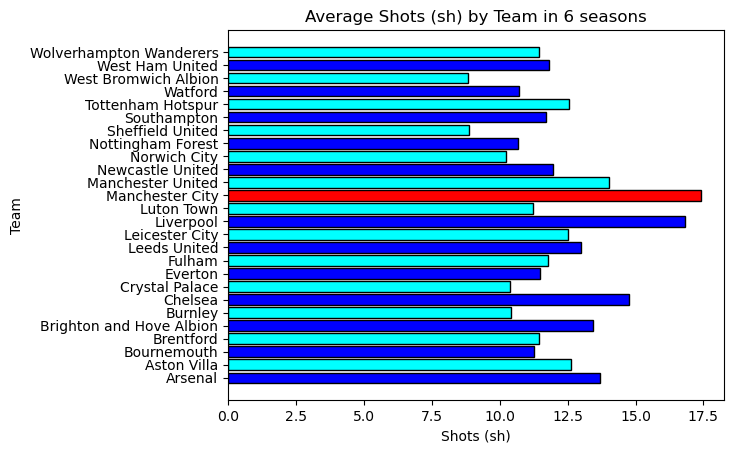

```python
tm = teams['team']
shoots = teams['sh']
max_shoots = shoots.argmax()
colors = ['blue','cyan']*len(tm)
colors[max_shoots]='red'
plt.barh(teams['team'], teams['sh'], color=colors, edgecolor='black')

plt.xlabel('Shots (sh)')
plt.ylabel('Team')
plt.title('Average Shots (sh) by Team in 6 seasons')
plt.show()
```

manchester city has the biggest Average shots in the premier league

west bromwich albion and sheffield united have the lowest shots rate

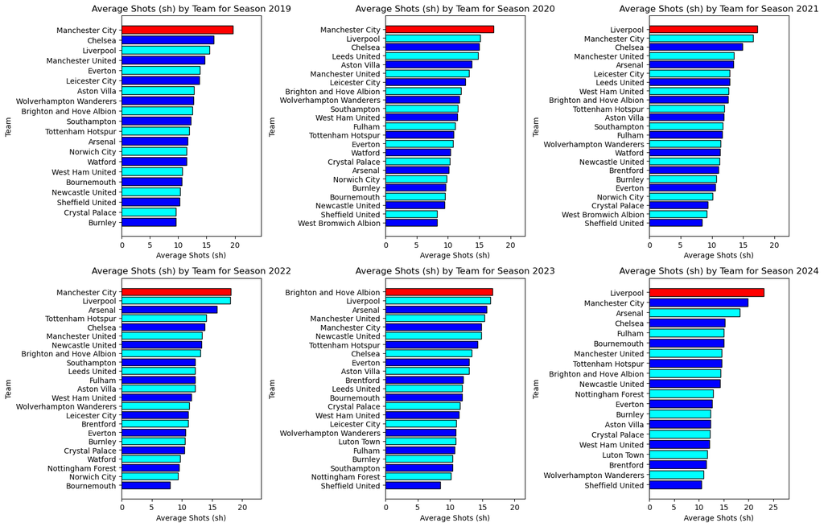

```python
if 'season' not in data.columns:
    raise ValueError("The 'season' column is missing from the dataset.")

# Get unique seasons
seasons = data['season'].unique()

fig, axs = plt.subplots(nrows=2, ncols=3, figsize=(15, 10))
axs = axs.flatten()  # Flatten the 2D array of axes to 1D for easy indexing

# Loop through each season and create a horizontal bar plot
for i, season in enumerate(seasons):
    # Group by 'team' for the specific season and calculate the mean of 'sh'
    teams_season = data[data['season'] == season].groupby('team')['sh'].mean().sort_values(ascending=True)

    # Get teams and their average shots
    tm = teams_season.index
    shoots = teams_season.values

    # Find the index of the maximum shots
    max_shoots_index = shoots.argmax()

    # Create a colors list for the bars
    colors = ['blue', 'cyan'] * (len(tm) // 2) + ['blue'] * (len(tm) % 2)

    # Set the color of the team with the maximum shots to red
    colors[max_shoots_index] = 'red'

    # Create the horizontal bar plot
    axs[i].barh(tm, shoots, color=colors, edgecolor='black')

    axs[i].set_xlabel('Average Shots (sh)')
    axs[i].set_ylabel('Team')
    axs[i].set_title(f'Average Shots (sh) by Team for Season {season}')
    axs[i].set_xlim(0, shoots.max() + 5)  # Set x-limit for better visibility

# Adjust layout for better spacing
plt.tight_layout()
plt.show()
```

# manchester city and liverpool have much shoots on the goal during the match

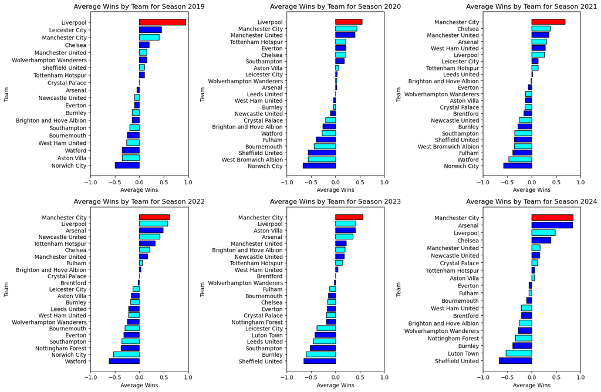

```python
# Ensure the 'season' column is in the dataset
if 'season' not in data.columns:
    raise ValueError("The 'season' column is missing from the dataset.")

# Get unique seasons
seasons = data['season'].unique()


fig, axs = plt.subplots(nrows=2, ncols=3, figsize=(15, 10))
axs = axs.flatten()  # Flatten the 2D array of axes to 1D for easy indexing

# Loop through each season and create a horizontal bar plot
for i, season in enumerate(seasons):
    # Group by 'team' for the specific season and calculate the mean of 'result'
    teams_season = data[data['season'] == season].groupby('team')['result'].mean().sort_values(ascending=True)

    # Get teams and their average wins
    tm = teams_season.index
    wins = teams_season.values

    # Find the index of the maximum wins
    max_wins_index = wins.argmax()

    # Create a colors list for the bars
    colors = ['blue', 'cyan'] * (len(tm) // 2) + ['blue'] * (len(tm) % 2)

    # Set the color of the team with the maximum wins to red
    colors[max_wins_index] = 'red'

    # Create the horizontal bar plot
    axs[i].barh(tm, wins, color=colors, edgecolor='black')

    axs[i].set_xlabel('Average Wins')
    axs[i].set_ylabel('Team')
    axs[i].set_title(f'Average Wins by Team for Season {season}')
    axs[i].set_xlim(-1, 1)  # Set x-limit for better visibility, as wins can be -1, 0, or 1

# Adjust layout for better spacing
plt.tight_layout()
plt.show()
```

# Manchester City boasts a formidable team, backed by an impressive four-year winning record

# On the other hand, Norwich City has struggled, consistently ranking as one of the weakest teams in the Premier League.

# detecting outliers

```python
new = pd.DataFrame()
for column in data.select_dtypes(include=['float64', 'int64']):
    if(column=='pk' or column=='pkatt'):
        new[column] = data[column]
        continue
    shoots = data[column]
    q1 = shoots.quantile(0.25)
    q3 = shoots.quantile(0.75)
    iqr = q3 - q1

    lower_bound = q1 - 1.5 * iqr
    upper_bound = q3 + 1.5 * iqr

    clean = shoots[(shoots >= lower_bound) & (shoots <= upper_bound)]

    new[column] = clean

new
```

|  | day | venue | result | gf | ga | xg | xga | poss_home | attendance | sh | sot | dist | fk | pk | pkatt | season | week | poss_away |
| --- | --- | --- | --- | --- | --- | --- | --- | --- | --- | --- | --- | --- | --- | --- | --- | --- | --- | --- |
| 3 | 1 | 2 | 0 | 1.0 | 1.0 | 1.3 | 1.3 | 47 | 10714.0 | 8.0 | 3.0 | 19.0 | 0.0 | 0 | 0 | 2019 | 1 | 53 |
| 4 | 1 | 1 | -1 | 0.0 | 5.0 | 1.1 | 3.2 | 43 | 59870.0 | 5.0 | 3.0 | 12.7 | 1.0 | 0 | 0 | 2019 | 1 | 57 |
| 5 | 1 | 1 | 1 | 3.0 | 1.0 | 2.4 | 0.7 | 70 | 60407.0 | NaN | 6.0 | 18.6 | 2.0 | 0 | 0 | 2019 | 1 | 30 |
| 6 | 1 | 2 | -1 | 0.0 | 3.0 | 1.2 | 0.9 | 53 | 19784.0 | 11.0 | 3.0 | 18.7 | 1.0 | 0 | 0 | 2019 | 1 | 47 |
| 7 | 1 | 2 | 0 | 0.0 | 0.0 | 1.1 | 0.9 | 64 | 25151.0 | 10.0 | 2.0 | 17.1 | 0.0 | 0 | 0 | 2019 | 1 | 36 |
| ... | ... | ... | ... | ... | ... | ... | ... | ... | ... | ... | ... | ... | ... | ... | ... | ... | ... | ... |
| 4781 | 2 | 2 | 1 | 4.0 | 2.0 | 3.4 | 1.1 | 46 | 17124.0 | 12.0 | 7.0 | 15.4 | 2.0 | 0 | 0 | 2024 | 38 | 54 |
| 4782 | 2 | 1 | 1 | 2.0 | 0.0 | NaN | 0.5 | 67 | 60059.0 | NaN | NaN | 14.8 | 0.0 | 0 | 0 | 2024 | 38 | 33 |
| 4783 | 2 | 2 | -1 | 0.0 | 2.0 | 0.5 | NaN | 33 | 60059.0 | 4.0 | 2.0 | 19.0 | 1.0 | 0 | 0 | 2024 | 38 | 67 |
| 4784 | 2 | 1 | -1 | 2.0 | 4.0 | 2.0 | 1.1 | 41 | 12027.0 | 14.0 | 5.0 | 19.3 | 2.0 | 1 | 1 | 2024 | 38 | 59 |
| 4785 | 2 | 2 | -1 | 1.0 | 3.0 | 0.4 | 1.9 | 29 | 55097.0 | 3.0 | 2.0 | 10.3 | 0.0 | 0 | 0 | 2024 | 38 | 71 |

4627 rows × 18 columns

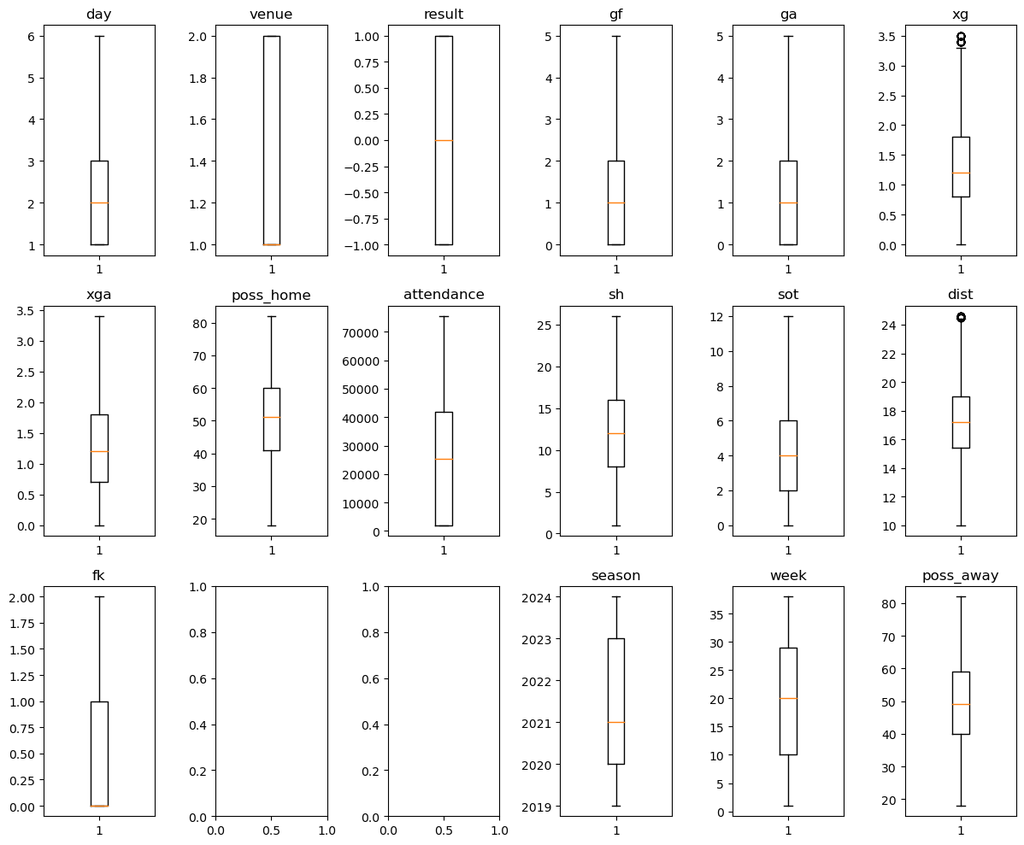

```python
fig, axs = plt.subplots(nrows=3, ncols=6, figsize=(12, 10))
axs = axs.flatten()


for idx, column in enumerate(new.columns):
    if(column=='pk' or column=='pkatt'):
        continue

    axs[idx].boxplot(new[column].dropna())
    axs[idx].set_title(column)

plt.tight_layout()
plt.show()
```

```python
print(new.isna().sum().to_frame(),"\n\n")

new.dropna(inplace=True)
print(new.isna().sum().to_frame())
```

```
             0
day          0
venue        0
result       0
gf          33
ga          31
xg          74
xga         81
poss_home    0
attendance   0
sh          67
sot         15
dist        96
fk          42
pk           0
pkatt        0
season       0
week         0
poss_away    0


            0
day         0
venue       0
result      0
gf          0
ga          0
xg          0
xga         0
poss_home   0
attendance  0
sh          0
sot         0
dist        0
fk          0
pk          0
pkatt       0
season      0
week        0
poss_away   0
```

```python
new
```

|  | day | venue | result | gf | ga | xg | xga | poss_home | attendance | sh | sot | dist | fk | pk | pkatt | season | week | poss_away |
| --- | --- | --- | --- | --- | --- | --- | --- | --- | --- | --- | --- | --- | --- | --- | --- | --- | --- | --- |
| 3 | 1 | 2 | 0 | 1.0 | 1.0 | 1.3 | 1.3 | 47 | 10714.0 | 8.0 | 3.0 | 19.0 | 0.0 | 0 | 0 | 2019 | 1 | 53 |
| 4 | 1 | 1 | -1 | 0.0 | 5.0 | 1.1 | 3.2 | 43 | 59870.0 | 5.0 | 3.0 | 12.7 | 1.0 | 0 | 0 | 2019 | 1 | 57 |
| 6 | 1 | 2 | -1 | 0.0 | 3.0 | 1.2 | 0.9 | 53 | 19784.0 | 11.0 | 3.0 | 18.7 | 1.0 | 0 | 0 | 2019 | 1 | 47 |
| 7 | 1 | 2 | 0 | 0.0 | 0.0 | 1.1 | 0.9 | 64 | 25151.0 | 10.0 | 2.0 | 17.1 | 0.0 | 0 | 0 | 2019 | 1 | 36 |
| 8 | 1 | 1 | 1 | 3.0 | 0.0 | 0.9 | 1.2 | 47 | 19784.0 | 10.0 | 4.0 | 15.0 | 0.0 | 0 | 0 | 2019 | 1 | 53 |
| ... | ... | ... | ... | ... | ... | ... | ... | ... | ... | ... | ... | ... | ... | ... | ... | ... | ... | ... |
| 4779 | 2 | 2 | -1 | 0.0 | 5.0 | 0.9 | 2.5 | 46 | 25191.0 | 8.0 | 2.0 | 13.8 | 0.0 | 0 | 0 | 2024 | 38 | 54 |
| 4780 | 2 | 1 | -1 | 1.0 | 2.0 | 1.2 | 1.7 | 72 | 21109.0 | 20.0 | 3.0 | 22.4 | 1.0 | 0 | 0 | 2024 | 38 | 28 |
| 4781 | 2 | 2 | 1 | 4.0 | 2.0 | 3.4 | 1.1 | 46 | 17124.0 | 12.0 | 7.0 | 15.4 | 2.0 | 0 | 0 | 2024 | 38 | 54 |
| 4784 | 2 | 1 | -1 | 2.0 | 4.0 | 2.0 | 1.1 | 41 | 12027.0 | 14.0 | 5.0 | 19.3 | 2.0 | 1 | 1 | 2024 | 38 | 59 |
| 4785 | 2 | 2 | -1 | 1.0 | 3.0 | 0.4 | 1.9 | 29 | 55097.0 | 3.0 | 2.0 | 10.3 | 0.0 | 0 | 0 | 2024 | 38 | 71 |

4248 rows × 18 columns